# Final Project

Sarah Lass

May 18, 2018

## Intro

What qualities make wine have a better taste? There are so many companies that make wine all over the world and they want people to enjoy and buy their products. Data was collected in 2009 about different physicochemical tests, like the pH level or the acidity level, to determine the quality of the wine based on median score given by three wine experts after tasting each sample (http://archive.ics.uci.edu/ml/datasets/Wine+Quality). This data is relevant becuase over the years the number of gallons of wine consumed per person per year in the US alone has increased by a half gallon from 2009 at 2.51 gallon to 2016 at 2.94 gallons (https://www.wineinstitute.org/resources/statistics/article86). This shows a growing industry where companies are going to want to make better quality wine to stand out in the competitive market. This also connects to data science becuase it can help businesses address the question of what characteristics of wine make for a better quality.

## Getting the Data

The data listed on the UCI Machine Learning Repository is given in a cvs file. This makes it easy to import into R. However, the data is given in one single column with each attribute separated by a semicolon.

```r
library(readr)

dataset <- read_csv("C:/Users/slass/Downloads/winequality-white.csv")
head(dataset)
```

```
## # A tibble: 6 x 1
##   `fixed acidity";"volatile acidity";"citric acid";"residual sugar";"chlo~
##   <chr>
## 1 7;0.27;0.36;20.7;0.045;45;170;1.001;3;0.45;8.8;6
## 2 6.3;0.3;0.34;1.6;0.049;14;132;0.994;3.3;0.49;9.5;6
## 3 8.1;0.28;0.4;6.9;0.05;30;97;0.9951;3.26;0.44;10.1;6
## 4 7.2;0.23;0.32;8.5;0.058;47;186;0.9956;3.19;0.4;9.9;6
## 5 7.2;0.23;0.32;8.5;0.058;47;186;0.9956;3.19;0.4;9.9;6
## 6 8.1;0.28;0.4;6.9;0.05;30;97;0.9951;3.26;0.44;10.1;6
```

To fix this issue, the column name of the data frames needs to be changed first so that any other cleaning can happen. Here the column name is changed to values as a temporary column name. Next, the rows can be separated with the separate function under the tidyr package (https://www.rdocumentation.org/packages/tidyr/versions/0.8.0/topics/separate). This function takes the data frame, called dataset, and the column that needs to be separated, called values, and separates the row by the regular expression or number given, in this case by a “;”. The types of the columns also needs to be converted to that they are not type character but the actual type, like double or int. This argument is called convert and it is set to true.

```r
library(tidyr)

colnames(dataset) <- "values"

wine <- separate(dataset, values, c("fixed_acidity","volatile_acidity","citric_acid","residual_sugar","chlorides","free_sulfur_dioxide","total_sulfur_dioxide","density","pH","sulphates","alcohol","quality"), sep = ";", convert = TRUE)
head(wine)
```

```
## # A tibble: 6 x 12
##   fixed_acidity volatile_acidity citric_acid residual_sugar chlorides
##           <dbl>            <dbl>       <dbl>          <dbl>     <dbl>
## 1           7               0.27        0.36           20.7     0.045
## 2           6.3             0.3         0.34            1.6     0.049
## 3           8.1             0.28        0.4             6.9     0.05
## 4           7.2             0.23        0.32            8.5     0.058
## 5           7.2             0.23        0.32            8.5     0.058
## 6           8.1             0.28        0.4             6.9     0.05
## # ... with 7 more variables: free_sulfur_dioxide <dbl>,
## #   total_sulfur_dioxide <dbl>, density <dbl>, pH <dbl>, sulphates <dbl>,
## #   alcohol <dbl>, quality <int>
```

```r
library(dplyr)
good <- c("6", "7", "8", "9", "10")
poor <- c("0", "1", "2", "3", "4", "5")

wineClass <- wine %>%
  mutate(qualitySuc = ifelse(quality %in% good, 1, 0))
wineClass <- wine[,-12]
head(wineClass)
```

```
## # A tibble: 6 x 11
##   fixed_acidity volatile_acidity citric_acid residual_sugar chlorides
##           <dbl>            <dbl>       <dbl>          <dbl>     <dbl>
## 1           7               0.27        0.36           20.7     0.045
## 2           6.3             0.3         0.34            1.6     0.049
## 3           8.1             0.28        0.4             6.9     0.05
## 4           7.2             0.23        0.32            8.5     0.058
## 5           7.2             0.23        0.32            8.5     0.058
## 6           8.1             0.28        0.4             6.9     0.05
## # ... with 6 more variables: free_sulfur_dioxide <dbl>,
## #   total_sulfur_dioxide <dbl>, density <dbl>, pH <dbl>, sulphates <dbl>,
## #   alcohol <dbl>
```

## Data Exploration

Next, it is important to perform exploratory data analysis on the data to get a better understanding of how to variables interact with one another and the response variable. Below there are two scatterplots that look to see if there is any relationship between some of the variable that sounded like they might be connected. It can be seen that free sulfer dioxide and total sufer dioxide have a positive linear relationship. This can be expected however becuase free sulfer dioxide is a proportion of the total sulfer dioxide. In the second graph, there does not seem to be a trend between fixed acidity and volatile acidity.

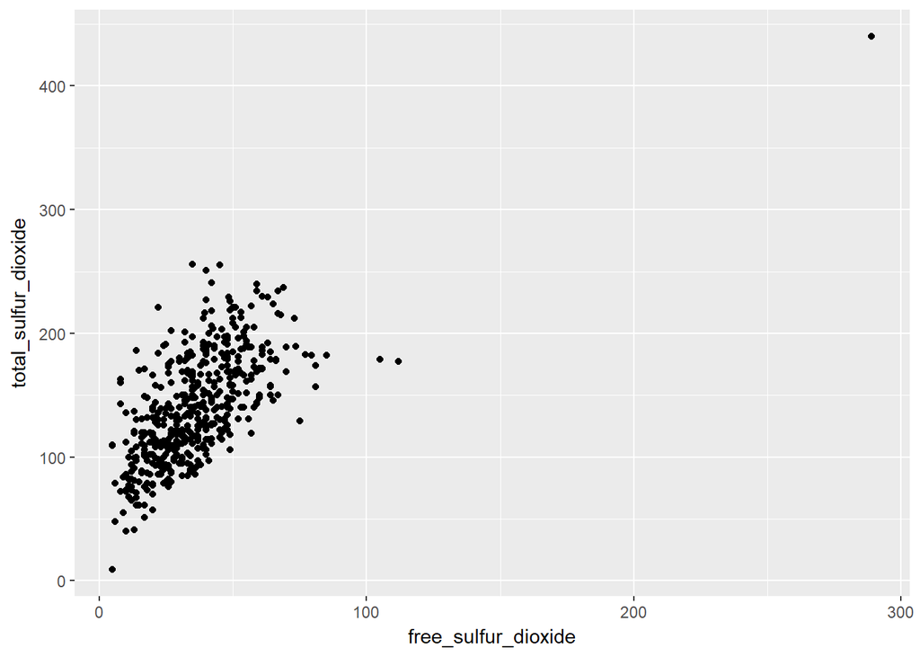

```r
library(dplyr)
library(tibble)
library(ggplot2)
wineClass %>%
  sample_frac(.1) %>%
  ggplot(aes(x=free_sulfur_dioxide, y=total_sulfur_dioxide)) +
    geom_point()
```

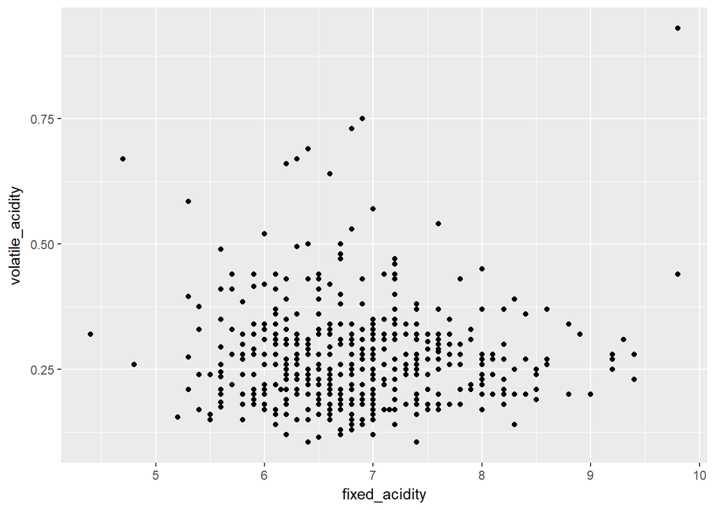

```r
wineClass %>%
  sample_frac(.1) %>%
  ggplot(aes(x=fixed_acidity, y=volatile_acidity)) +
    geom_point()
```

## Hypothesis Testing

For the question of this project, we will be determining what type of classification method is the best to classify wine as good or poor quality